# NBA

SEZYUEN_YIN

2018年12月19日

# NBA dataset from kaggle

The data-set contains aggregate individual statistics for 67 NBA seasons. from basic box-score attributes such as points, assists, rebounds etc., to more advanced money-ball like features such as Value Over Replacement.

## import packages

Import essential packages for data manipulation.

```r
library(dplyr)
```

```r
library(ggplot2)
library(readr)
library(naniar)
```

## import the data set

The original data set is well collected and saved as a csv file. So it is easy to import the data set.

```
## Observations: 24,691
## Variables: 53
## $ X1      <int> 0, 1, 2, 3, 4, 5, 6, 7, 8, 9, 10, 11, 12, 13, 14, 15, ...
## $ Year    <int> 1950, 1950, 1950, 1950, 1950, 1950, 1950, 1950, 1950, ...
## $ Player  <chr> "Curly Armstrong", "Cliff Barker", "Leo Barnhorst", "E...
## $ Pos     <chr> "G-F", "SG", "SF", "F", "F", "F", "G", "G-F", "F-C", "...
## $ Age     <int> 31, 29, 25, 24, 24, 24, 22, 23, 28, 28, 28, 25, 22, 22...
## $ Tm      <chr> "FTW", "INO", "CHS", "TOT", "DNN", "NYK", "INO", "TRI"...
## $ G       <int> 63, 49, 67, 15, 13, 2, 60, 3, 65, 36, 29, 57, 60, 59, ...
## $ GS      <chr> NA, NA, NA, NA, NA, NA, NA, NA, NA, NA, NA, NA, NA, NA...
## $ MP      <int> NA, NA, NA, NA, NA, NA, NA, NA, NA, NA, NA, NA, NA, NA...
## $ PER     <dbl> NA, NA, NA, NA, NA, NA, NA, NA, NA, NA, NA, NA, NA, NA...
## $ `TS%`   <dbl> 0.368, 0.435, 0.394, 0.312, 0.308, 0.376, 0.422, 0.275...
## $ `3PAr`  <chr> NA, NA, NA, NA, NA, NA, NA, NA, NA, NA, NA, NA, NA, NA...
## $ FTr     <dbl> 0.467, 0.387, 0.259, 0.395, 0.378, 0.750, 0.301, 0.313...
```

[output cut: 40 more lines]

There are 53 variables and 24691 obvs in the data set. However, some meanless variables occur and we will deal with it later. More importantly, some of the variables were not recorded at the early time of NBA, such as 3P%. (There is no 3 points line at that time!). We must keep that in mind

```r
colnames(org_data)
```

```
##  [1] "X1"     "Year"   "Player" "Pos"    "Age"    "Tm"     "G"
##  [8] "GS"     "MP"     "PER"    "TS%"    "3PAr"   "FTr"    "ORB%"
## [15] "DRB%"   "TRB%"   "AST%"   "STL%"   "BLK%"   "TOV%"   "USG%"
## [22] "blanl"  "OWS"    "DWS"    "WS"     "WS/48"  "blank2" "OBPM"
## [29] "DBPM"   "BPM"    "VORP"   "FG"     "FGA"    "FG%"    "3P"
## [36] "3PA"    "3P%"    "2P"     "2PA"    "2P%"    "eFG%"   "FT"
## [43] "FTA"    "FT%"    "ORB"    "DRB"    "TRB"    "AST"    "STL"
## [50] "BLK"    "TOV"    "PF"     "PTS"
```

```r
# Drop meanless variables
drop_cols <- c("X1", "blanl", "blank2")
org_data <- org_data %>% select(-one_of(drop_cols))
```

## Getting feel of missing data

```r
org_data <- as.data.frame(org_data)
miss_var_sum <- miss_var_summary(org_data)
miss_var_sum
```

```
## # A tibble: 50 x 3
##    variable n_miss pct_miss
##    <chr>     <int>    <dbl>
##  1 3P%        9275     37.6
##  2 GS         6458     26.2
##  3 3PAr       5852     23.7
##  4 3P         5764     23.3
##  5 3PA        5764     23.3
##  6 TOV%       5109     20.7
##  7 USG%       5051     20.5
##  8 TOV        5046     20.4
##  9 ORB%       3899     15.8
## 10 DRB%       3899     15.8
## # ... with 40 more rows
```

The variables associate with 3 pts are missed heavily. It is because 3 pts had not brought into NBA until 1980. The same thing happend to TOV, ORB, DRB, STL and BLK.Considering those stat importance, we create subsets only including those possessing it.

Before create subsets, some variables must convert to numeric type.

```r
cols_to_conv <- c("3PAr", "ORB%", "DRB%", "TRB%", "AST%", "STL%", "BLK%", "TOV%", "USG%", "OBPM", "DBPM", "BPM", "VORP", "3P", "3PA", "3P%", "ORB", "DRB", "STL",
                  "BLK", "TOV")
org_data[, cols_to_conv] <- sapply(org_data[, cols_to_conv], as.numeric)

colnames(org_data)[which(names(org_data) == "3PAr")] <- "ThreePAr"
colnames(org_data)[which(names(org_data) == "3P")] <- "ThreeP"
colnames(org_data)[which(names(org_data) == "3PA")] <- "ThreePA"
colnames(org_data)[which(names(org_data) == "3P%")] <- "ThreeP%"
colnames(org_data)[which(names(org_data) == "2P")] <- "TwoP"
colnames(org_data)[which(names(org_data) == "2PA")] <- "TwoPA"
colnames(org_data)[which(names(org_data) == "2P%")] <- "TwoP%"

Three_data <- filter(org_data, !is.na(ThreeP))
miss_var_sum_for3 <- miss_var_summary(Three_data)
head(miss_var_sum_for3, n=20)
```

```
## # A tibble: 20 x 3
##    variable n_miss pct_miss
##    <chr>     <int>    <dbl>
##  1 ThreeP%    3511  18.6
##  2 FT%         745   3.94
##  3 GS          694   3.67
##  4 TwoP%       117   0.618
##  5 ThreePAr     88   0.465
##  6 FTr          88   0.465
##  7 FG%          88   0.465
##  8 eFG%         88   0.465
##  9 TS%          76   0.402
## 10 TOV%         61   0.322
## 11 PER           5   0.0264
## 12 ORB%          5   0.0264
## 13 DRB%          5   0.0264
## 14 TRB%          5   0.0264
## 15 AST%          5   0.0264
## 16 STL%          5   0.0264
## 17 BLK%          5   0.0264
## 18 USG%          5   0.0264
## 19 WS/48         5   0.0264
## 20 Year          0   0
```

可以看到，还有3511个观察的3P%显示为missing，这个是由于这些观察的3分球出手与命中数都为0所导致的（分母为0），因此，将这种情况下的NA全部替换为数值0

```r
Three_data %>% filter(ThreeP == 0 & ThreePA == 0) %>% count() # Exactly 3511 obs
```

```
## # A tibble: 1 x 1
##       n
##   <int>
## 1  3511
```

```r
Three_data$`ThreeP%` <- replace(Three_data$`ThreeP%`, is.na(Three_data$`ThreeP%`), 0)
miss_var_summary(Three_data)
```

```
## # A tibble: 50 x 3
##    variable n_miss pct_miss
##    <chr>     <int>    <dbl>
##  1 FT%         745   3.94
##  2 GS          694   3.67
##  3 TwoP%       117   0.618
##  4 ThreePAr     88   0.465
##  5 FTr          88   0.465
##  6 FG%          88   0.465
##  7 eFG%         88   0.465
##  8 TS%          76   0.402
##  9 TOV%         61   0.322
## 10 PER           5   0.0264
## # ... with 40 more rows
```

另外，当FGA等于0时，TwoP%, ThreePAr, FG%, eFG%, TS%都应该等于0

```r
filter(Three_data, is.na(Three_data$`FG%`) & FGA !=0)
```

```
##  [1] Year     Player   Pos      Age      Tm       G        GS
##  [8] MP       PER      TS%      ThreePAr FTr      ORB%     DRB%
## [15] TRB%     AST%     STL%     BLK%     TOV%     USG%     OWS
## [22] DWS      WS       WS/48    OBPM     DBPM     BPM      VORP
## [29] FG       FGA      FG%      ThreeP   ThreePA  ThreeP%  TwoP
## [36] TwoPA    TwoP%    eFG%     FT       FTA      FT%      ORB
## [43] DRB      TRB      AST      STL      BLK      TOV      PF
## [50] PTS
## <0 rows> (or 0-length row.names)
```

```r
Three_data$ThreePAr <- replace(Three_data$ThreePAr, is.na(Three_data$ThreePAr), 0)
miss_var_sum_for3 <- miss_var_summary(Three_data)
```

所有3分球出手相关的数据已经准备好了。

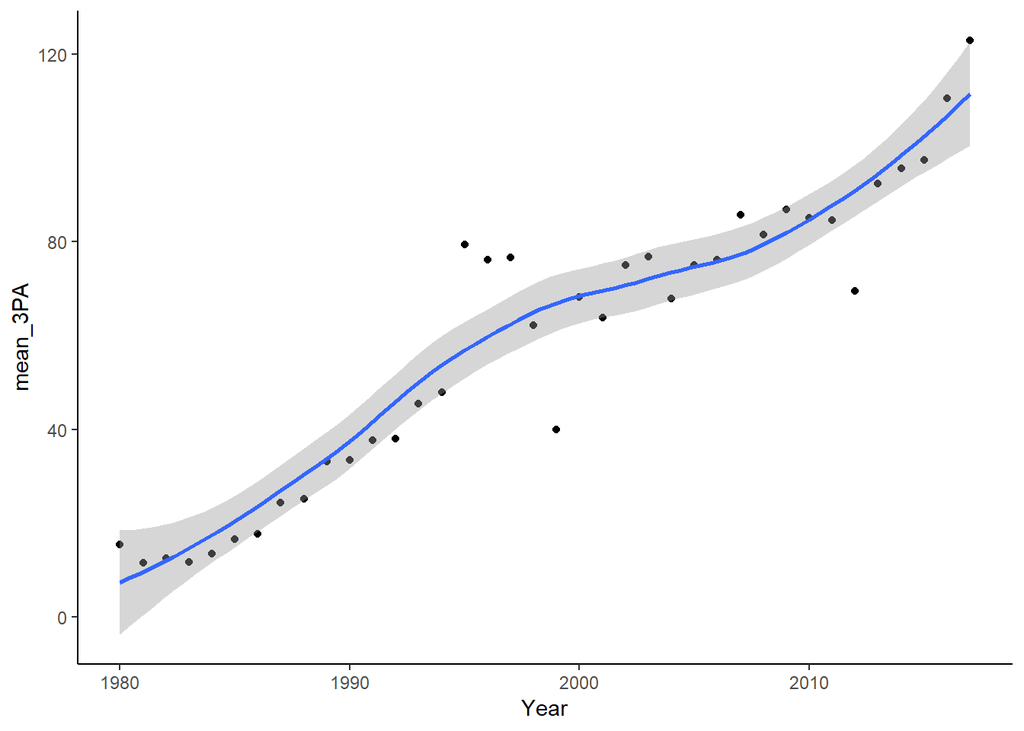

```r
Three_data %>% group_by(Year) %>% summarise(mean_3PA = mean(ThreePA)) %>% ggplot(aes(x = Year, y = mean_3PA)) + geom_point() + geom_smooth() + theme_classic()
```

从图中可以看出，自1980年引入3分球以来，3分球的出手数量逐年递增（除了1999年及2012年受到NBA停摆的影响以外）。而这其中又有一些特别的年份需要注意，如1995<sub>1997和2016</sub>2017年。

在此之前，先让我们看看过去30多年里球员的3分球命中率是怎么的？由于有许多球员并不出手3分球，所以他们的3分球命中率为0，为了剔除这部分球员的影响，这里采用中位数衡量每个赛季的3分球命中率情况。

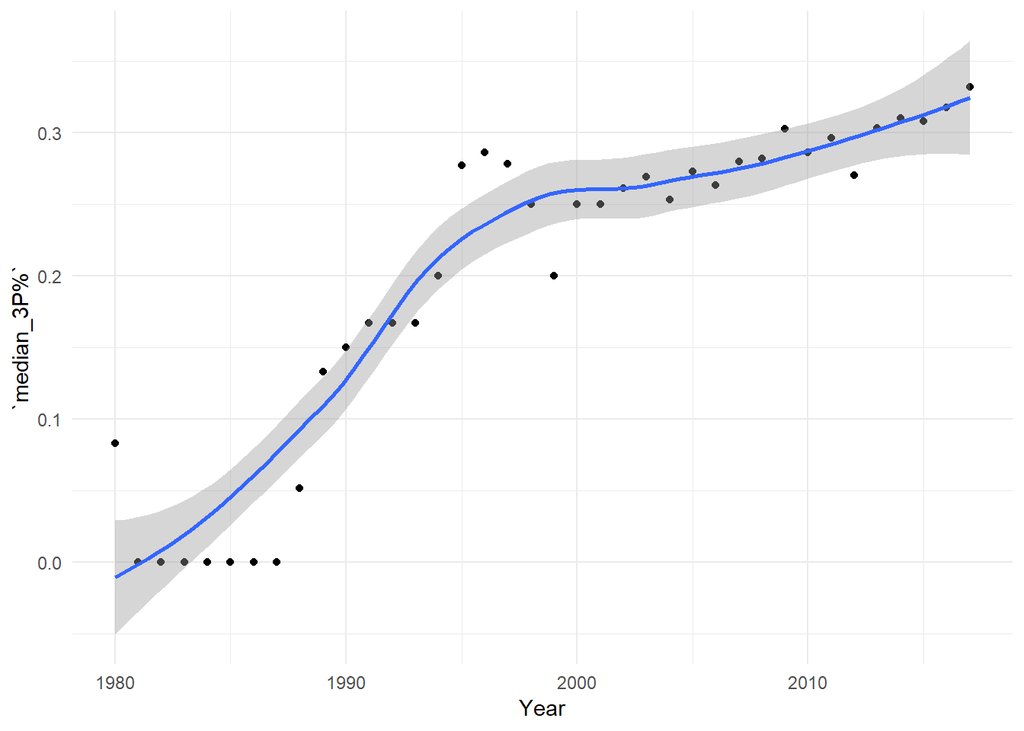

```r
Three_data %>% group_by(Year) %>% summarise(`median_3P%` = median(`ThreeP%`)) %>% ggplot(aes(x = Year, y =`median_3P%`)) +geom_point() + geom_smooth() +theme_minimal()
```

可以看到，在3分球刚引入联盟的时候，3分球并不受人待见，甚至在80年代出现持续3分球命中率的中位数为0，也就是说起码有一半的球员从来就没有命中过3分球。与3分球出手数的情况类似，3分球命中率在95、96、97这3年出现异常的提高。在这几个年份中发生了什么？首先看看这几个年份中3分出手的球员。

```r
Three_data %>% filter(Year %in% c(1995, 1996, 1997)) %>% select(Year, Player, ThreePA, ThreeP, `ThreeP%`, ThreePAr) %>% group_by(Year) %>% arrange(Year, desc(ThreePA)) %>% filter(row_number() <= 10)
```

```
## # A tibble: 30 x 6
## # Groups:   Year [3]
##     Year Player          ThreePA ThreeP `ThreeP%` ThreePAr
##    <int> <chr>             <dbl>  <dbl>     <dbl>    <dbl>
##  1  1995 John Starks         611    217     0.355    0.575
##  2  1995 Mookie Blaylock     555    199     0.359    0.463
##  3  1995 Dan Majerle         548    199     0.363    0.532
##  4  1995 Nick Van            511    183     0.358    0.462
##  5  1995 Reggie Miller*      470    195     0.415    0.43
##  6  1995 Glen Rice           451    185     0.41     0.321
##  7  1995 Chuck Person        445    172     0.387    0.593
##  8  1995 Tim Hardaway        444    168     0.378    0.441
##  9  1995 Vernon Maxwell      441    143     0.324    0.568
## 10  1995 Nick Anderson       431    179     0.415    0.467
## # ... with 20 more rows
```

```r
Three_data %>% filter(Year %in% c(1993, 1994, 1998)) %>% select(Year, Player, ThreePA, ThreeP, `ThreeP%`, ThreePAr) %>% group_by(Year) %>% arrange(Year, desc(ThreePA)) %>% filter(row_number() <= 10)
```

```
## # A tibble: 30 x 6
## # Groups:   Year [3]
##     Year Player             ThreePA ThreeP `ThreeP%` ThreePAr
##    <int> <chr>                <dbl>  <dbl>     <dbl>    <dbl>
##  1  1993 Dan Majerle            438    167     0.381    0.4
##  2  1993 Reggie Miller*         419    167     0.399    0.351
##  3  1993 Glen Rice              386    148     0.383    0.292
##  4  1993 Danny Ainge            372    150     0.403    0.51
##  5  1993 Vernon Maxwell         361    120     0.332    0.421
##  6  1993 Terry Porter           345    143     0.414    0.311
##  7  1993 John Starks            336    108     0.321    0.28
##  8  1993 Chuck Person           332    118     0.355    0.266
##  9  1993 Dominique Wilkins*     316    120     0.38     0.199
## 10  1993 Mookie Blaylock        315    118     0.375    0.327
## # ... with 20 more rows
```

三分狂人的出现。在1995~1997三个赛季中，分别涌现出多位3分狂人，他们单季的3分球出手数超过了600次，而在往前和往后的93、94及98的赛季中都没有这样的三分出手狂人。其中在1995年John Starcks出手611次三分球，1996年George McCloud出手678次三分球，还有Dennis Scott和Mookie Blaylock分别出手628次及623次，1997年Mookie Blaylock出手604次三分球。而且在这3个赛季中，3分球出手数前10的球员总体也多于相邻的几个赛季。

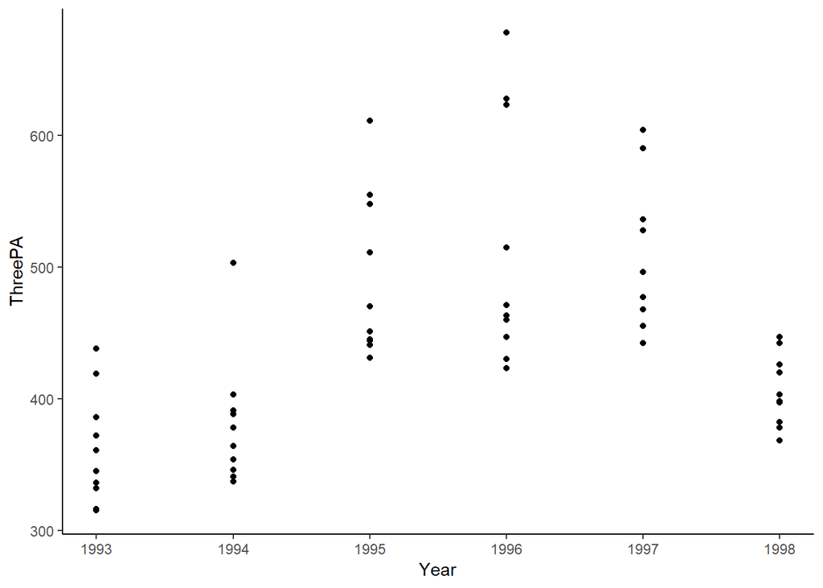

```r
# Most 3PTA players during 1993 ~ 1999
Three_data %>% filter(Year %in% c(1993,1994,1995,1996,1997,1998)) %>% select(Year, Player, ThreePA, ThreeP, `ThreeP%`, ThreePAr) %>% group_by(Year) %>% arrange(Year, desc(ThreePA)) %>% filter(row_number() <= 10) %>% ggplot(aes(x = Year, y = ThreePA)) + geom_point() + theme_classic()
```

但是，这几个赛季中的3分狂人大多都难以持续表现，连续3年出现在95~97的3分出手前10榜单的球员仅有1人，为Mookie Blaylock

```r
Three_95_top10 <- Three_data %>% filter(Year == 1995) %>% select(Year, Player, ThreePA, ThreeP, `ThreeP%`, ThreePAr) %>% group_by(Year) %>% arrange(Year, desc(ThreePA)) %>% filter(row_number() <= 10)

Three_96_top10 <- Three_data %>% filter(Year == 1996) %>% select(Year, Player, ThreePA, ThreeP, `ThreeP%`, ThreePAr) %>% group_by(Year) %>% arrange(Year, desc(ThreePA)) %>% filter(row_number() <= 10)

Three_97_top10 <- Three_data %>% filter(Year == 1997) %>% select(Year, Player, ThreePA, ThreeP, `ThreeP%`, ThreePAr) %>% group_by(Year) %>% arrange(Year, desc(ThreePA)) %>% filter(row_number() <= 10)

Three_95_top10 %>% inner_join(Three_96_top10, by = 'Player') %>% inner_join(Three_97_top10, by = 'Player')
```

```
## # A tibble: 1 x 16
## # Groups:   Year.x [?]
##   Year.x Player ThreePA.x ThreeP.x `ThreeP%.x` ThreePAr.x Year.y ThreePA.y
##    <int> <chr>      <dbl>    <dbl>       <dbl>      <dbl>  <int>     <dbl>
## 1   1995 Mooki~       555      199       0.359      0.463   1996       623
## # ... with 8 more variables: ThreeP.y <dbl>, `ThreeP%.y` <dbl>,
## #   ThreePAr.y <dbl>, Year <int>, ThreePA <dbl>, ThreeP <dbl>,
## #   `ThreeP%` <dbl>, ThreePAr <dbl>
```

那么，在2016和2017年的故事又是怎样的呢？

```r
Three_data %>% filter(Year %in% c(2015,2016,2017)) %>% select(Year, Player, ThreePA, ThreeP, `ThreeP%`, ThreePAr) %>% group_by(Year) %>% arrange(Year, desc(ThreePA)) %>% filter(row_number() <= 10)
```

```
## # A tibble: 30 x 6
## # Groups:   Year [3]
##     Year Player           ThreePA ThreeP `ThreeP%` ThreePAr
##    <int> <chr>              <dbl>  <dbl>     <dbl>    <dbl>
##  1  2015 Stephen Curry        646    286     0.443    0.482
##  2  2015 Damian Lillard       572    196     0.343    0.421
##  3  2015 Trevor Ariza         555    194     0.35     0.61
##  4  2015 James Harden         555    208     0.375    0.378
##  5  2015 Klay Thompson        545    239     0.439    0.42
##  6  2015 J.J. Redick          458    200     0.437    0.488
##  7  2015 Danny Green          457    191     0.418    0.619
##  8  2015 Kyle Korver          449    221     0.492    0.748
##  9  2015 Lou Williams         447    152     0.34     0.482
## 10  2015 Robert Covington     446    167     0.374    0.59
## # ... with 20 more rows
```

在2016和2017的两个赛季中，库里连续两年霸占三分球出手次数第1（其实从2013年开始就是他），这与之前95~97赛季的3分狂人情况大大不同。 那么，库里究竟在3分球上为什么是历史级别

# Stephen Curry

在这份数据中，与3分球相关的主要数据有ThreePA（出手数），ThreeP（命中数），ThreeP%（命中率），ThreePAr（出手率）。先前我们已经大致看到了NBA历史三分球出手数的走势，但衡量一个优秀的三分手，命中数和命中率才是更有效的指标。那么库里的这两项指标在历史中是什么水平呢？

首先需要将三分球命中数为0的obs剔除，再在此基础上考察一下三分球命中数（ThreeP）的分布情况。

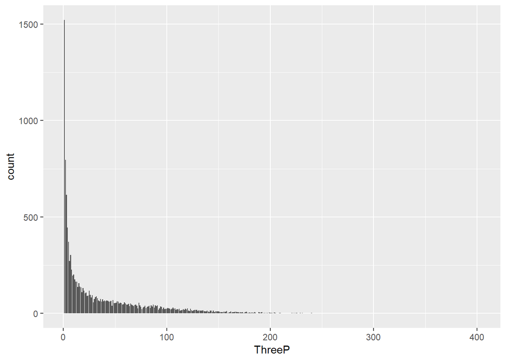

```r
Made_3_data <- Three_data %>% filter(ThreeP > 0)

Made_3_data %>% ggplot(aes(ThreeP)) + geom_bar()
```

可以看到ThreeP有明显的长尾，大部分obs单季的三分球命中数都在100一下。我们考察一下具体的分位数。

```r
quantile(Made_3_data$ThreeP)
```

```
##   0%  25%  50%  75% 100%
##    1    4   17   54  402
```

可以看到，有50%的obs单季三分球命中数在17个及一下。单季三分球命中数在17个及以下很难被认为是一名3分球投手，因此我们把这部分obs也剔除在讨论之外。

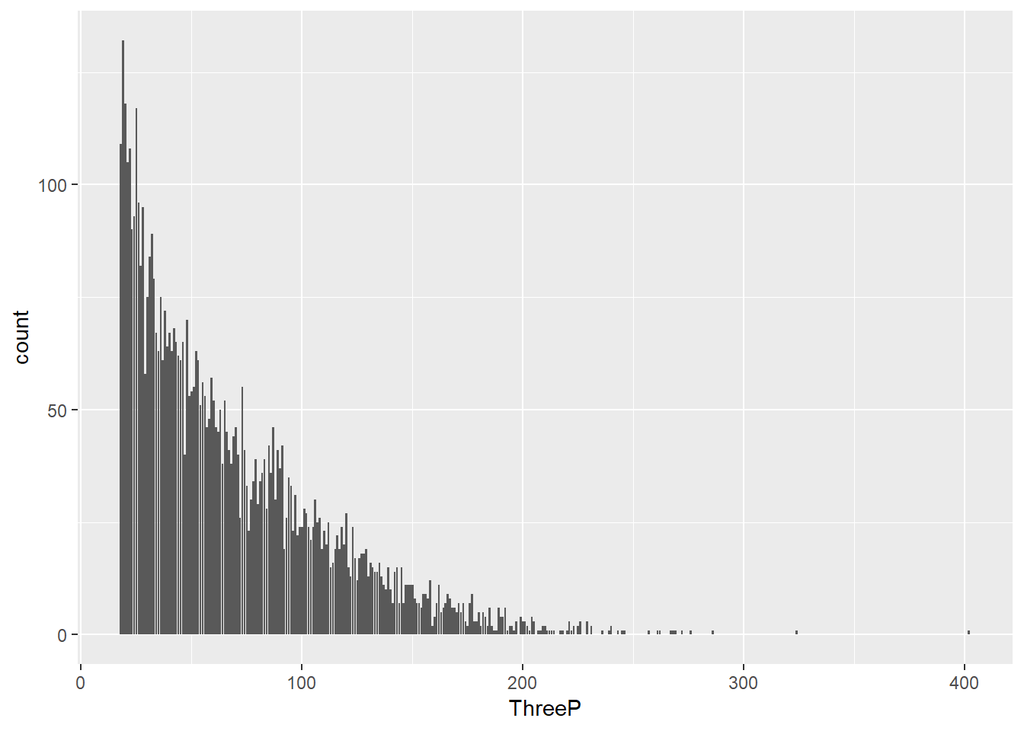

```r
Made_3_data <- Made_3_data %>% filter(ThreeP > 17)

Made_3_data %>% ggplot(aes(ThreeP)) + geom_bar()
```

```r
print(quantile(Made_3_data$ThreeP))
```

```
##   0%  25%  50%  75% 100%
##   18   32   55   91  402
```

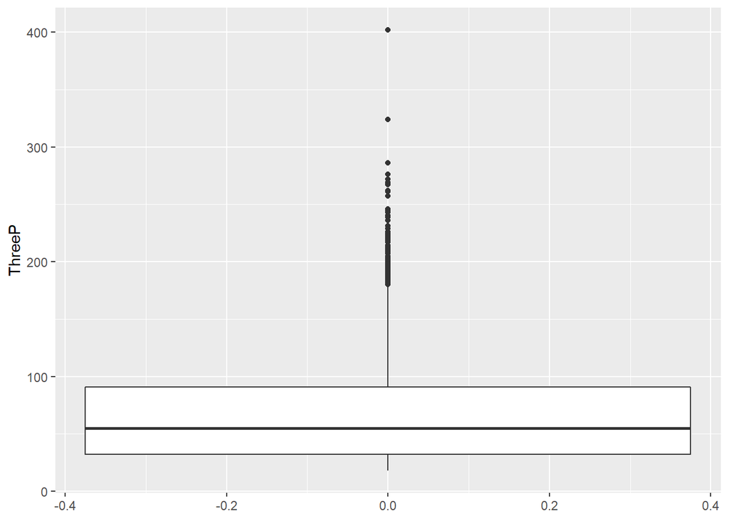

```r
ggplot(Made_3_data, aes(y=ThreeP)) + geom_boxplot()
```

此时三分球命中数的中位数为55，上分位数为91。 再来看看这些球员在三分球命中数和三分球命中率这两项数据上的分布情况。

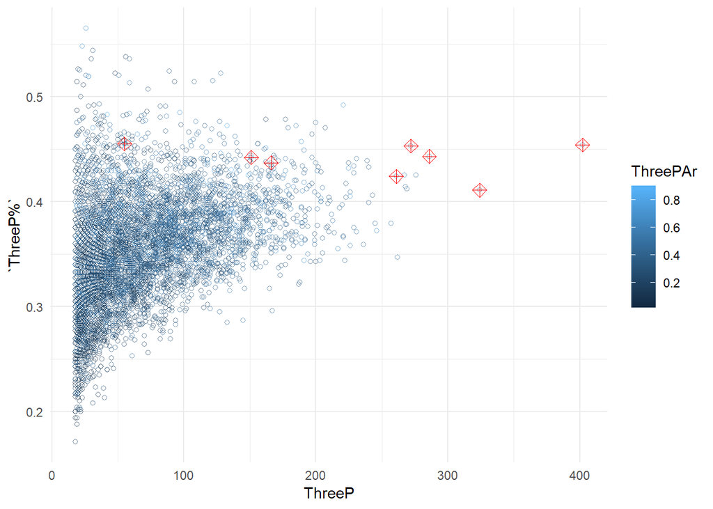

```r
curry_summary <- Made_3_data %>% filter(Player == 'Stephen Curry') %>% select(ThreeP, `ThreeP%`)

Made_3_data %>% ggplot(aes(x = ThreeP, y = `ThreeP%`, color = ThreePAr)) + geom_point(shape = 1, alpha = 0.6) + geom_point(data = curry_summary, shape = 9, size = 3, color = 'red') +theme_minimal()
```

库里是NBA历史上唯一一位单季三分球命中数大于400的球员（甚至大于300也是唯一一位）。而他的三分球命中率也远高于平均水准。接下来我们就来看看球员三分球命中率的情况。

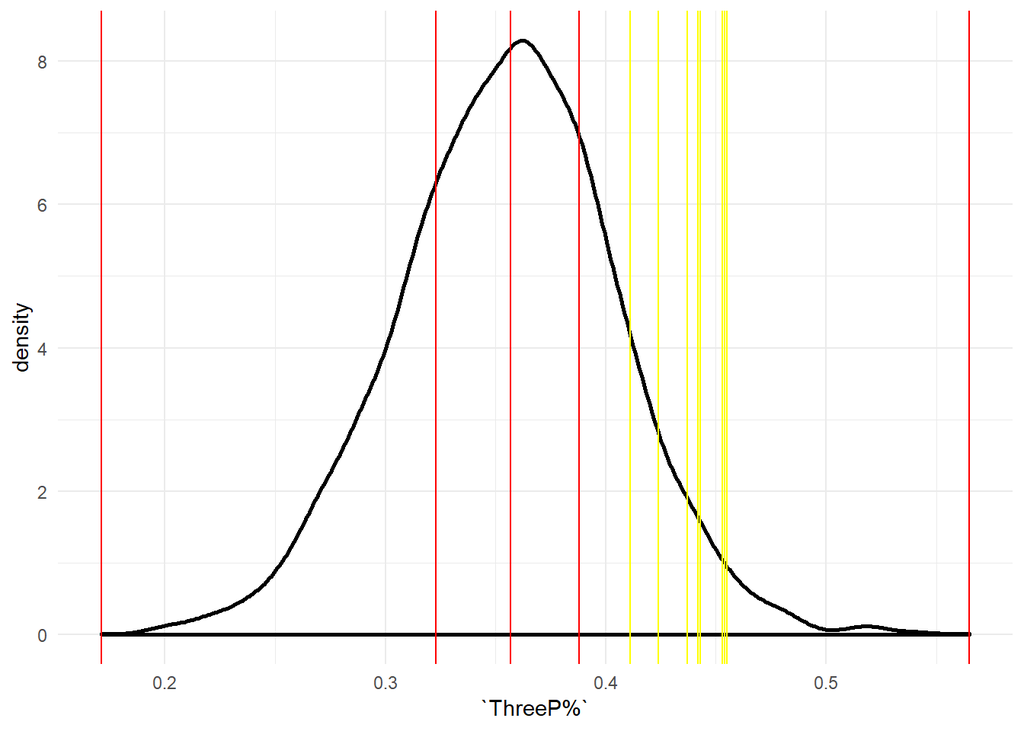

```r
Made_3_data %>% ggplot(aes(`ThreeP%`)) + geom_density(size=1) + geom_vline(xintercept = curry_summary$`ThreeP%`, color = 'yellow') + geom_vline(xintercept = quantile(Made_3_data$`ThreeP%`), color = 'red') + theme_minimal()
```

库里所有赛季的三分球命中率都高于40%，全部高于75%分位数。而在单季命中100球及以上3分的球员中，库里的表现依旧出色，三分球命中率同样全部超过75%分位数。

```r
Made_3_100_data <- Made_3_data %>% filter(ThreeP >= 100)

#Made_3_100_data %>% ggplot(aes(`ThreeP%`)) + geom_density() + geom_vline(xintercept = curry_summary$`ThreeP%`, color = 'yellow') + geom_vline(xintercept = quantile(Made_3_100_data$`ThreeP%`), color = 'red')

Made_3_100_data %>% select(Year, Player, `ThreeP%`, ThreeP) %>% arrange(desc(`ThreeP%`))
```

```
##      Year                   Player ThreeP% ThreeP
## 1    1996               Tim Legler   0.522    128
## 2    1996               Steve Kerr   0.515    122
## 3    2007             Jason Kapono   0.514    108
## 4    2015              Kyle Korver   0.492    221
## 5    1989               Dale Ellis   0.478    162
## 6    2005              Joe Johnson   0.478    177
## 7    1996             Hubert Davis   0.476    127
## 8    2001              Brent Barry   0.476    109
## 9    2016              J.J. Redick   0.475    200
## 10   2002              Steve Smith   0.472    116
## 11   2012              Steve Novak   0.472    133
## 12   2014              Kyle Korver   0.472    185
## 13   1997                Glen Rice   0.470    207
## 14   2008               Steve Nash   0.470    179
```

[output cut: 1185 more lines]

在2016年，库里以45.4%的单季三分球命中率（生涯最高，NBA历史第31位）投进402记三分球（NBA记录）

# 伟大的3分手

伟大的3分手首先就是要投进足够多的3分球，这里我对3分球命中数排在历史前300的球员进行汇总。第300名的是Robert Covington，命中了478记3分球。

```r
Top_300_3_pointer <- Three_data %>% select(Year, Player, `ThreeP%`, ThreeP, ThreePAr) %>% group_by(Player) %>% summarise(Total_3 = sum(ThreeP)) %>% arrange(desc(Total_3))  %>% filter(row_number() <= 300)

tail(Top_300_3_pointer)
```

```
## # A tibble: 6 x 2
##   Player                   Total_3
##   <chr>                      <dbl>
## 1 Earl Boykins                 490
## 2 Omri Casspi                  483
## 3 Detlef Schrempf              482
## 4 Evan Fournier                480
## 5 Kentavious Caldwell-Pope     479
## 6 Robert Covington             478
```

将这份300人的名单和Three_data进行inner_join之后，就可以得到这300人在每个赛季的表现。接下来就让我们看看有什么有趣的。

```r
Top_300_3_pointer_seasonal <- inner_join(Three_data, Top_300_3_pointer, by = 'Player') %>% group_by(Year) %>% distinct(Player, .keep_all = TRUE) %>% ungroup()
```

首先看看这300人的首秀时间（这里指的是有3分球记录以来的时间即1980年，如拉里伯德虽然在1979年就登陆NBA，但是这份名单中任按照1980年的数据为初始。另外，由于这里的300人是根据职业生涯的总三分球命中数筛选出来的，所以近年出现在名单中的球员数量自然较少）。

可以看到，1999年有17位球员最终上榜了该300人名单，为历史最多（当然，这份名单很快就会被更新）。这17人中包含了文斯卡特、德克诺维斯基、保罗皮尔斯、佩贾斯托克亚维齐等大名鼎鼎的名字。

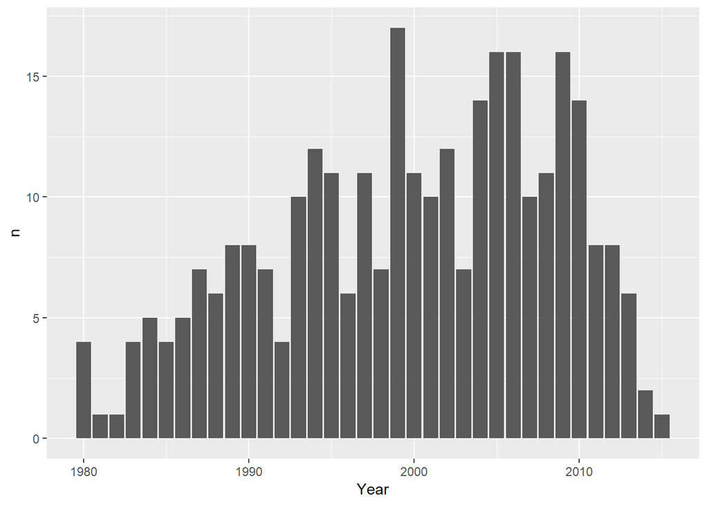

```r
Top_300_3_pointer_seasonal %>% distinct(Player, .keep_all = TRUE) %>% group_by(Year) %>% count()  %>% ggplot(aes(x = Year, y = n)) + geom_col()
```

```r
Top_300_3_pointer_seasonal %>% distinct(Player, .keep_all = TRUE) %>% group_by(Year) %>% count()
```

```
## # A tibble: 36 x 2
## # Groups:   Year [36]
##     Year     n
##    <int> <int>
##  1  1980     4
##  2  1981     1
##  3  1982     1
##  4  1983     4
##  5  1984     5
##  6  1985     4
##  7  1986     5
##  8  1987     7
##  9  1988     6
## 10  1989     8
## # ... with 26 more rows
```

```r
Top_300_3_pointer_seasonal %>% distinct(Player, .keep_all = TRUE) %>% group_by(Year) %>% filter(Year == 1999)
```

```
## # A tibble: 17 x 51
## # Groups:   Year [1]
##     Year Player   Pos     Age Tm        G GS       MP   PER `TS%` ThreePAr
##    <int> <chr>    <chr> <int> <chr> <int> <chr> <int> <dbl> <dbl>    <dbl>
##  1  1999 Mike Bi~ PG       20 VAN      50 50     1758  14.8 0.487    0.122
##  2  1999 Earl Bo~ PG       22 TOT      22 0       221   7.2 0.405    0.228
##  3  1999 Vince C~ SF       22 TOR      50 49     1760  19.6 0.516    0.086
##  4  1999 Ricky D~ SG       19 CHH      46 1       557  12.9 0.462    0.06
##  5  1999 Pat Gar~ PF       22 PHO      39 9       538  13   0.557    0.106
##  6  1999 Al Harr~ PF       18 IND      21 0       160   6.4 0.359    0.089
##  7  1999 Larry H~ PG       20 PHI      50 1       988  16.7 0.474    0.126
##  8  1999 Antawn ~ SF       22 GSW      47 24     1058  16.6 0.487    0.025
##  9  1999 Damon J~ PG       22 TOT      24 0       344  13.7 0.494    0.521
## 10  1999 Raef La~ C        22 DEN      12 12      387  18.9 0.553    0.24
## 11  1999 Rashard~ SF       19 SEA      20 7       145   4.5 0.404    0.115
## 12  1999 Tyronn ~ PG       21 LAL      15 0       188  11.2 0.505    0.246
## 13  1999 Cuttino~ PG       23 HOU      49 37     1456  12.2 0.537    0.365
## 14  1999 Dirk No~ PF       20 DAL      47 24      958  12.8 0.491    0.202
## 15  1999 Paul Pi~ SF       21 BOS      48 47     1632  19.2 0.54     0.315
## 16  1999 Peja St~ SF       21 SAC      48 1      1025  13.5 0.496    0.477
## 17  1999 Jason W~ PG       23 SAC      50 50     1805  12.8 0.483    0.524
## # ... with 40 more variables: FTr <dbl>, `ORB%` <dbl>, `DRB%` <dbl>,
## #   `TRB%` <dbl>, `AST%` <dbl>, `STL%` <dbl>, `BLK%` <dbl>, `TOV%` <dbl>,
## #   `USG%` <dbl>, OWS <dbl>, DWS <dbl>, WS <dbl>, `WS/48` <dbl>,
## #   OBPM <dbl>, DBPM <dbl>, BPM <dbl>, VORP <dbl>, FG <int>, FGA <int>,
## #   `FG%` <dbl>, ThreeP <dbl>, ThreePA <dbl>, `ThreeP%` <dbl>, TwoP <int>,
## #   TwoPA <int>, `TwoP%` <dbl>, `eFG%` <dbl>, FT <int>, FTA <int>,
## #   `FT%` <dbl>, ORB <dbl>, DRB <dbl>, TRB <int>, AST <int>, STL <dbl>,
## #   BLK <dbl>, TOV <dbl>, PF <int>, PTS <int>, Total_3 <dbl>
```

而在2012年，这份名单中的164人同时活跃在联盟，其中就包括历史三分王雷阿伦，也有斯提夫库里和克莱汤普森等未来的三分球霸主，当然也有如科比布兰恩特、卡梅隆安东尼、凯文杜兰特这样的历史级得分手。

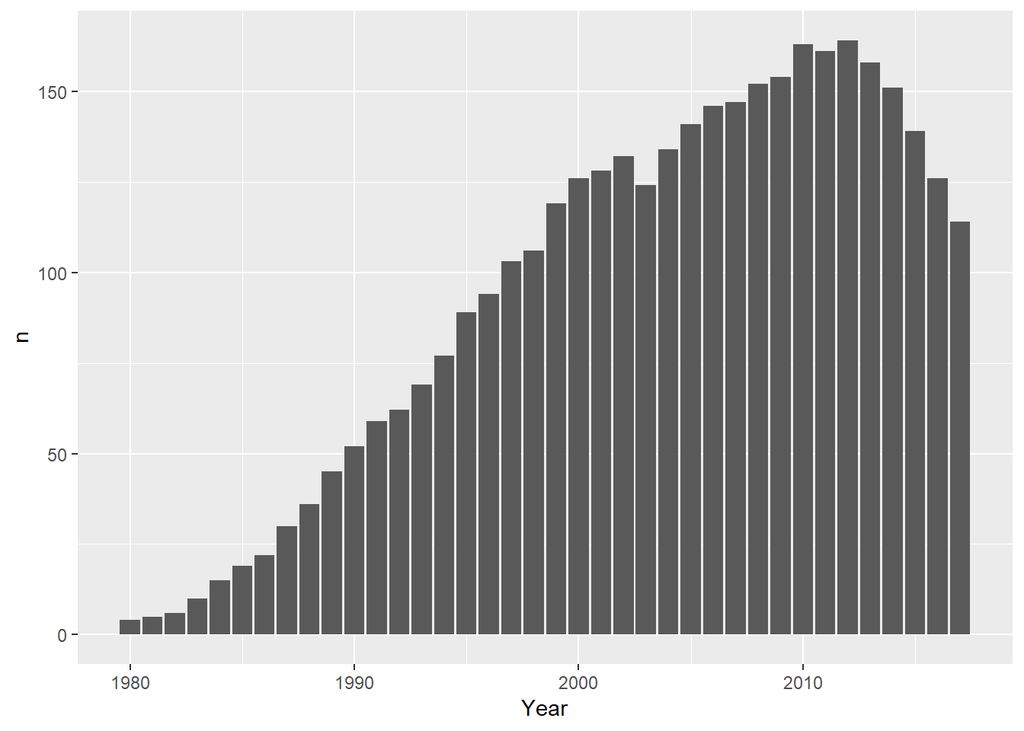

```r
Top_300_3_pointer_seasonal%>% group_by(Year) %>% count()  %>% ggplot(aes(x = Year, y = n)) + geom_col()
```

```r
Top_300_3_pointer_seasonal %>% group_by(Year)%>% filter(Year == 2012)
```

```
## # A tibble: 164 x 51
## # Groups:   Year [1]
##     Year Player   Pos     Age Tm        G GS       MP   PER `TS%` ThreePAr
##    <int> <chr>    <chr> <int> <chr> <int> <chr> <int> <dbl> <dbl>    <dbl>
##  1  2012 Arron A~ SG       26 DEN      62 62     2086  14.7 0.584    0.316
##  2  2012 Ray All~ SG       36 BOS      46 42     1565  14.8 0.607    0.475
##  3  2012 Ryan An~ PF       23 ORL      61 61     1964  21.2 0.589    0.557
##  4  2012 Carmelo~ SF       27 NYK      55 55     1876  21.1 0.525    0.198
##  5  2012 Gilbert~ PG       30 MEM      17 0       211   9.9 0.526    0.609
##  6  2012 Trevor ~ SF       26 NOH      41 41     1350  14.2 0.496    0.216
##  7  2012 D.J. Au~ PG       24 CHA      48 46     1408  14.1 0.493    0.368
##  8  2012 Leandro~ SG       29 TOT      64 0      1382  14   0.512    0.267
##  9  2012 J.J. Ba~ PG       27 MIN      41 11     1032  14.9 0.502    0.342
## 10  2012 Andrea ~ C        26 TOR      31 31     1032  17.9 0.538    0.238
## # ... with 154 more rows, and 40 more variables: FTr <dbl>, `ORB%` <dbl>,
## #   `DRB%` <dbl>, `TRB%` <dbl>, `AST%` <dbl>, `STL%` <dbl>, `BLK%` <dbl>,
## #   `TOV%` <dbl>, `USG%` <dbl>, OWS <dbl>, DWS <dbl>, WS <dbl>,
## #   `WS/48` <dbl>, OBPM <dbl>, DBPM <dbl>, BPM <dbl>, VORP <dbl>,
## #   FG <int>, FGA <int>, `FG%` <dbl>, ThreeP <dbl>, ThreePA <dbl>,
## #   `ThreeP%` <dbl>, TwoP <int>, TwoPA <int>, `TwoP%` <dbl>, `eFG%` <dbl>,
## #   FT <int>, FTA <int>, `FT%` <dbl>, ORB <dbl>, DRB <dbl>, TRB <int>,
## #   AST <int>, STL <dbl>, BLK <dbl>, TOV <dbl>, PF <int>, PTS <int>,
## #   Total_3 <dbl>
```

## 王中之王

历史排名前300的三分手究竟谁最出色？

```r
Top_300_3_pointer_seasonal <- Top_300_3_pointer_seasonal %>% mutate(Year_Player = paste(Year, Player, sep = "_"))

#Top_300_3_pointer_seasonal %>% ggplot(aes(ThreeP)) + geom_density()

Cluster_Top_300_data <- Top_300_3_pointer_seasonal %>% filter(ThreeP > 15 & `ThreeP%` > 0.26 & ThreePAr > 0.11) %>% select(ThreePAr, ThreeP, ThreePA, `ThreeP%`)
```

```r
# Check if scaling is necessary
colMeans(Cluster_Top_300_data)
```

```
##    ThreePAr      ThreeP     ThreePA     ThreeP%
##   0.3602247  88.8467054 240.7698873   0.3653711
```

```r
apply(Cluster_Top_300_data, 2, sd)
```

```
##     ThreePAr       ThreeP      ThreePA      ThreeP%
##   0.14141928  46.56093667 117.53888571   0.04355042
```

```r
# Produce new matrix with columns of mean of 0 and sd of 1
scaled_Cluster_Top_300_data <- scale(Cluster_Top_300_data)

colMeans(scaled_Cluster_Top_300_data)
```

```
##      ThreePAr        ThreeP       ThreePA       ThreeP%
##  3.093008e-17 -6.332066e-17 -2.778400e-17 -5.889437e-16
```

```r
apply(scaled_Cluster_Top_300_data, 2, sd)
```

```
## ThreePAr   ThreeP  ThreePA  ThreeP%
##        1        1        1        1
```

```r
# Hierarchical cluster

hclust_Top_300 <- hclust(dist(scaled_Cluster_Top_300_data), method = "complete")

cut_Top_300 <- cutree(hclust_Top_300, k = 5)

table(cut_Top_300)
```

```
## cut_Top_300
##    1    2    3    4    5
## 1086  399 1289  153    2
```

```r
Cluster_result <- Top_300_3_pointer_seasonal %>% filter(ThreeP > 15 & `ThreeP%` > 0.26 & ThreePAr > 0.11) %>% bind_cols(as.data.frame(cut_Top_300)) %>% rename(clusters = cut_Top_300)

colnames(Cluster_result)
```

```
##  [1] "Year"        "Player"      "Pos"         "Age"         "Tm"
##  [6] "G"           "GS"          "MP"          "PER"         "TS%"
## [11] "ThreePAr"    "FTr"         "ORB%"        "DRB%"        "TRB%"
## [16] "AST%"        "STL%"        "BLK%"        "TOV%"        "USG%"
## [21] "OWS"         "DWS"         "WS"          "WS/48"       "OBPM"
## [26] "DBPM"        "BPM"         "VORP"        "FG"          "FGA"
## [31] "FG%"         "ThreeP"      "ThreePA"     "ThreeP%"     "TwoP"
## [36] "TwoPA"       "TwoP%"       "eFG%"        "FT"          "FTA"
## [41] "FT%"         "ORB"         "DRB"         "TRB"         "AST"
## [46] "STL"         "BLK"         "TOV"         "PF"          "PTS"
## [51] "Total_3"     "Year_Player" "clusters"
```

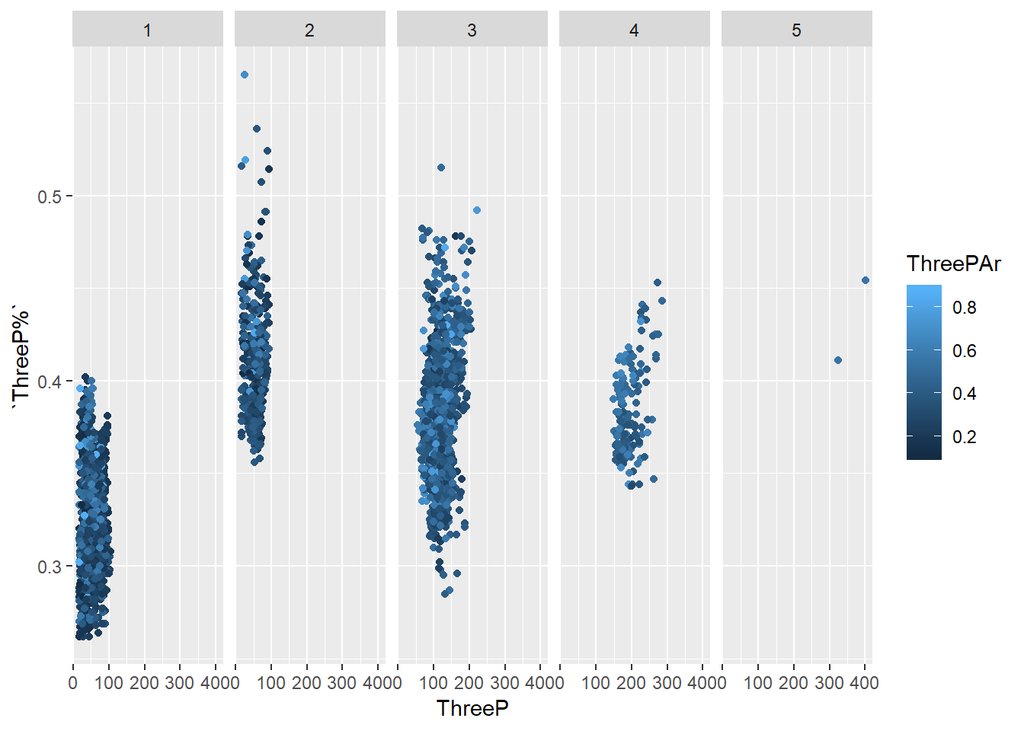

```r
Cluster_result %>% ggplot(aes(x = ThreeP, y = `ThreeP%`, color = ThreePAr)) + geom_point() + facet_grid(.~clusters)
```

```r
Cluster_result %>% filter(Player == "Stephen Curry") %>% select(Year_Player, clusters)
```

```
## # A tibble: 8 x 2
##   Year_Player        clusters
##   <chr>                 <int>
## 1 2010_Stephen Curry        3
## 2 2011_Stephen Curry        3
## 3 2012_Stephen Curry        2
## 4 2013_Stephen Curry        4
## 5 2014_Stephen Curry        4
## 6 2015_Stephen Curry        4
## 7 2016_Stephen Curry        5
## 8 2017_Stephen Curry        5
```

```r
cluster4 <- Cluster_result %>% filter(clusters == 4) %>% select(Year_Player, Year, Player, ThreePAr, `ThreeP%`, ThreeP, ThreePA)
cluster3 <- Cluster_result %>% filter(clusters == 3) %>% select(Year_Player, Year, Player, ThreePAr, `ThreeP%`, ThreeP, ThreePA)
cluster2 <- Cluster_result %>% filter(clusters == 2) %>% select(Year_Player, Year, Player, ThreePAr, `ThreeP%`, ThreeP, ThreePA)
cluster1 <- Cluster_result %>% filter(clusters == 1) %>% select(Year_Player, Year, Player, ThreePAr, `ThreeP%`, ThreeP, ThreePA)
```

```r
Cluster_result %>% group_by(clusters)  %>% summarise(mean_ThreeP = mean(ThreeP), mean_ThreePA = mean(ThreePA), mean_ThreePercent = mean(`ThreeP%`), mean_ThreePAr = mean(ThreePAr))
```

```
## # A tibble: 5 x 5
##   clusters mean_ThreeP mean_ThreePA mean_ThreePercent mean_ThreePAr
##      <int>       <dbl>        <dbl>             <dbl>         <dbl>
## 1        1        53.0         162.             0.328         0.305
## 2        2        55.7         137.             0.410         0.335
## 3        3       116.          307.             0.381         0.401
## 4        4       193.          504.             0.384         0.477
## 5        5       363           838.             0.432         0.550
```

```r
cluster4 %>% group_by(Player) %>% count() %>% arrange(desc(n))
```

```
## # A tibble: 81 x 2
## # Groups:   Player [81]
##    Player               n
##    <chr>            <int>
##  1 Ray Allen            7
##  2 J.R. Smith           6
##  3 Damian Lillard       5
##  4 James Harden         5
##  5 Klay Thompson        5
##  6 Wesley Matthews      5
##  7 Damon Stoudamire     3
##  8 Dan Majerle          3
##  9 Gilbert Arenas       3
## 10 Jamal Crawford       3
## # ... with 71 more rows
```

```r
cluster3 %>% group_by(Player) %>% count() %>% arrange(desc(n))
```

```
## # A tibble: 279 x 2
## # Groups:   Player [279]
##    Player               n
##    <chr>            <int>
##  1 Paul Pierce         15
##  2 Vince Carter        15
##  3 Reggie Miller*      14
##  4 Chauncey Billups    13
##  5 Jason Terry         13
##  6 Jason Kidd          12
##  7 Joe Johnson         12
##  8 Dirk Nowitzki       11
##  9 Jamal Crawford      11
## 10 Kyle Korver         11
## # ... with 269 more rows
```

```r
cluster2 %>% group_by(Player) %>% count() %>% arrange(desc(n))
```

```
## # A tibble: 183 x 2
## # Groups:   Player [183]
##    Player               n
##    <chr>            <int>
##  1 Steve Kerr           9
##  2 Steve Nash           8
##  3 Jose Calderon        7
##  4 Trent Tucker         7
##  5 Wally Szczerbiak     7
##  6 Chris Mullin*        6
##  7 Dana Barros          6
##  8 James Jones          6
##  9 Jeff Hornacek        6
## 10 John Stockton*       6
## # ... with 173 more rows
```

```r
cluster1 %>% group_by(Player) %>% count() %>% arrange(desc(n))
```

```
## # A tibble: 280 x 2
## # Groups:   Player [280]
##    Player               n
##    <chr>            <int>
##  1 Allen Iverson*      12
##  2 Jerry Stackhouse    12
##  3 Lamar Odom          10
##  4 Metta World         10
##  5 Mike Dunleavy       10
##  6 Rodney Rogers       10
##  7 Ron Harper          10
##  8 Toni Kukoc          10
##  9 Devin Harris         9
## 10 Jalen Rose           9
## # ... with 270 more rows
```